# House Pricing Prediction

#### Group 11: Yazid Mouline & Guillaume Requena | AML Class 2020

```python
pip install impyute
```

```python
#imports
import matplotlib.pyplot as plt
import matplotlib
import numpy as np
import pandas as pd
import seaborn as sns

from google.colab import drive
from pandas_profiling import ProfileReport
from sklearn.impute import KNNImputer
from impyute.imputation.cs import mice
from scipy.stats import skew
import matplotlib.lines as mlines
import matplotlib.transforms as mtransforms
from time import time

from sklearn.metrics import mean_squared_error
from sklearn.metrics import r2_score
```

### Data importation

```python
drive.mount('/content/drive/',force_remount=True)
```

```
Go to this URL in a browser: https://accounts.google.com/o/oauth2/auth?client_id=947318989803-6bn6qk8qdgf4n4g3pfee6491hc0brc4i.apps.googleusercontent.com&redirect_uri=urn%3aietf%3awg%3aoauth%3a2.0%3aoob&response_type=code&scope=email%20https%3a%2f%2fwww.googleapis.com%2fauth%2fdocs.test%20https%3a%2…

Enter your authorization code:
··········
```

```python
train = pd.read_csv('/content/drive/My Drive/AML/Chal1 - House/Data/train.csv')
test = pd.read_csv('/content/drive/My Drive/AML/Chal1 - House/Data/test.csv')
```

## 1. Data preparation

### 1.1. Data exploration

#### 1.1.1. Data cleaning

For all the data cleaning part, we'll concatenate the train and test sets, to ensure that all modification will be the same for both and to facilitate our work.

```python
test_index = len(train)
dataset = pd.concat([train, test], ignore_index=True)
```

##### 1.1.1.a. Handling NULL values

```python
dataset = dataset.drop('Id' , axis=1)
#dropping the useless column ID
dataset
```

|  | MSSubClass | MSZoning | LotFrontage | LotArea | Street | Alley | LotShape | LandContour | Utilities | LotConfig | LandSlope | Neighborhood | Condition1 | Condition2 | BldgType | HouseStyle | OverallQual | OverallCond | YearBuilt | YearRemodAdd | RoofStyle | RoofMatl | Exterior1st | Exterior2nd | MasVnrType | MasVnrArea | ExterQual | ExterCond | Foundation | … |
| --- | --- | --- | --- | --- | --- | --- | --- | --- | --- | --- | --- | --- | --- | --- | --- | --- | --- | --- | --- | --- | --- | --- | --- | --- | --- | --- | --- | --- | --- | --- |
| 0 | 60 | RL | 65.0 | 8450 | Pave | NaN | Reg | Lvl | AllPub | Inside | Gtl | CollgCr | Norm | Norm | 1Fam | 2Story | 7 | 5 | 2003 | 2003 | Gable | CompShg | VinylSd | VinylSd | BrkFace | 196.0 | Gd | TA | PConc | … |
| 1 | 20 | RL | 80.0 | 9600 | Pave | NaN | Reg | Lvl | AllPub | FR2 | Gtl | Veenker | Feedr | Norm | 1Fam | 1Story | 6 | 8 | 1976 | 1976 | Gable | CompShg | MetalSd | MetalSd | None | 0.0 | TA | TA | CBlock | … |
| 2 | 60 | RL | 68.0 | 11250 | Pave | NaN | IR1 | Lvl | AllPub | Inside | Gtl | CollgCr | Norm | Norm | 1Fam | 2Story | 7 | 5 | 2001 | 2002 | Gable | CompShg | VinylSd | VinylSd | BrkFace | 162.0 | Gd | TA | PConc | … |
| 3 | 70 | RL | 60.0 | 9550 | Pave | NaN | IR1 | Lvl | AllPub | Corner | Gtl | Crawfor | Norm | Norm | 1Fam | 2Story | 7 | 5 | 1915 | 1970 | Gable | CompShg | Wd Sdng | Wd Shng | None | 0.0 | TA | TA | BrkTil | … |
| 4 | 60 | RL | 84.0 | 14260 | Pave | NaN | IR1 | Lvl | AllPub | FR2 | Gtl | NoRidge | Norm | Norm | 1Fam | 2Story | 8 | 5 | 2000 | 2000 | Gable | CompShg | VinylSd | VinylSd | BrkFace | 350.0 | Gd | TA | PConc | … |
| ... | ... | ... | ... | ... | ... | ... | ... | ... | ... | ... | ... | ... | ... | ... | ... | ... | ... | ... | ... | ... | ... | ... | ... | ... | ... | ... | ... | ... | ... | … |
| 1455 | 60 | RL | 62.0 | 7917 | Pave | NaN | Reg | Lvl | AllPub | Inside | Gtl | Gilbert | Norm | Norm | 1Fam | 2Story | 6 | 5 | 1999 | 2000 | Gable | CompShg | VinylSd | VinylSd | None | 0.0 | TA | TA | PConc | … |
| 1456 | 20 | RL | 85.0 | 13175 | Pave | NaN | Reg | Lvl | AllPub | Inside | Gtl | NWAmes | Norm | Norm | 1Fam | 1Story | 6 | 6 | 1978 | 1988 | Gable | CompShg | Plywood | Plywood | Stone | 119.0 | TA | TA | CBlock | … |
| 1457 | 70 | RL | 66.0 | 9042 | Pave | NaN | Reg | Lvl | AllPub | Inside | Gtl | Crawfor | Norm | Norm | 1Fam | 2Story | 7 | 9 | 1941 | 2006 | Gable | CompShg | CemntBd | CmentBd | None | 0.0 | Ex | Gd | Stone | … |
| 1458 | 20 | RL | 68.0 | 9717 | Pave | NaN | Reg | Lvl | AllPub | Inside | Gtl | NAmes | Norm | Norm | 1Fam | 1Story | 5 | 6 | 1950 | 1996 | Hip | CompShg | MetalSd | MetalSd | None | 0.0 | TA | TA | CBlock | … |
| 1459 | 20 | RL | 75.0 | 9937 | Pave | NaN | Reg | Lvl | AllPub | Inside | Gtl | Edwards | Norm | Norm | 1Fam | 1Story | 5 | 6 | 1965 | 1965 | Gable | CompShg | HdBoard | HdBoard | None | 0.0 | Gd | TA | CBlock | … |

1460 rows × 80 columns

```python
dataset.info()
```

```
<class 'pandas.core.frame.DataFrame'>
RangeIndex: 1460 entries, 0 to 1459
Data columns (total 80 columns):
 #   Column         Non-Null Count  Dtype
---  ------         --------------  -----
 0   MSSubClass     1460 non-null   int64
 1   MSZoning       1460 non-null   object
 2   LotFrontage    1201 non-null   float64
 3   LotArea        1460 non-null   int64
 4   Street         1460 non-null   object
 5   Alley          91 non-null     object
 6   LotShape       1460 non-null   object
 7   LandContour    1460 non-null   object
 8   Utilities      1460 non-null   object
 9   LotConfig      1460 non-null   object
```

[output cut: 72 more lines]

```python
null_values = dataset.isnull().sum().sort_values(ascending = False)
null_values[:20]
```

```
PoolQC          1453
MiscFeature     1406
Alley           1369
Fence           1179
FireplaceQu      690
LotFrontage      259
GarageType        81
GarageCond        81
GarageFinish      81
GarageQual        81
GarageYrBlt       81
BsmtFinType2      38
BsmtExposure      38
BsmtQual          37
BsmtCond          37
BsmtFinType1      37
MasVnrArea         8
MasVnrType         8
Electrical         1
RoofMatl           0
dtype: int64
```

For some features, ratio of NaN values is ridiculous. These features are PoolQC, MiscFeature, Alley, Fence, FirePlaceQu. However, we choose to keep these features instead of simply deleting them because we believe that they have a real added value to the house.

We have to deal with these NaN values. 'NA' attributes have been misgiven for Nulls, we thus have to replace them accoridingly if it's a numerical feature or a categorical feature.

There are three numerical feature where there are Nan values, two of them are surfaces, so it makes sense to put a zero instead of a NaN. The feature GarageYrBlt is disturbing, it is a date, so replacing NaN by a zero will be dangerous. We choose then to delete this column. Plus, it doesn't add up much information.

However, we have to deal with all the features (pretending that we don't have access to the test set). For the numerical features, there should not be a problem. We'll replace all by 0 since they are all surfaces, or prices, except for MoSold, YrSold, YearBuilt and YearRemodAdd that should all be filled.

For the categorical features, we'll only replace all by 'NA' as intended in the original dataset.

```python
dataset = dataset.drop('GarageYrBlt' , axis=1) #dropping the column GarageYrBlt another way would be to use knn or mice (if we have time)

categorical_features = list(dataset.select_dtypes(include=object).columns)
numerical_features = list(dataset.select_dtypes(exclude=object).columns)

dataset[numerical_features] = dataset[numerical_features].fillna(0) #filling Nan values with 0

dataset[categorical_features] = dataset[categorical_features].fillna('NA') #filling Nan values with NA as intended in the dataset
```

We dealt with all the NaN values, now we have to treat all the categorical features, replacing them with numerical features, or do some k-encoding.

##### 1.1.1.b. Categorical features encoding

We choose to do both techniques, convert some features into numerical features, and convert other features into many cloumns with boolean values (k-encoding). We will do this to try to limit the number of added columns, when we can replace into a numerical feature, we'll do so. This will be the case when there is a potential scale (Ex, Gd, TA, Fa, Po for example).

```python
categorical_features
```

```
['MSZoning',
 'Street',
 'Alley',
 'LotShape',
 'LandContour',
 'Utilities',
 'LotConfig',
 'LandSlope',
 'Neighborhood',
 'Condition1',
 'Condition2',
 'BldgType',
 'HouseStyle',
 'RoofStyle',
 'RoofMatl',
 'Exterior1st',
 'Exterior2nd',
 'MasVnrType',
 'ExterQual',
 'ExterCond',
 'Foundation',
 'BsmtQual',
 'BsmtCond',
 'BsmtExposure',
 'BsmtFinType1',
 'BsmtFinType2',
 'Heating',
 'HeatingQC',
 'CentralAir',
 'Electrical',
 'KitchenQual',
 'Functional',
 'FireplaceQu',
 'GarageType',
 'GarageFinish',
 'GarageQual',
 'GarageCond',
 'PavedDrive',
 'PoolQC',
 'Fence',
 'MiscFeature',
 'SaleType',
 'SaleCondition']
```

In this section, we deal with the categorical features that can be ordered in a certain scale. It is a bit dangerous to assume that these features have a linear scale, and could alter our results. However, it reduces greatly our number of features.

```python
categorical_features_scale1 = ['ExterQual', 'ExterCond',
                               'BsmtCond','BsmtQual',
                               'HeatingQC','KitchenQual','FireplaceQu',
                               'GarageQual','GarageCond','PoolQC']
categorical_features_scale2 = ['BsmtExposure']
categorical_features_scale3 = ['BsmtFinType1', 'BsmtFinType2']
categorical_features_scale4 = ['CentralAir']

scale1 = {'NA':np.nan,'Po':2, 'Fa':3, 'TA':4, 'Gd':5, 'Ex':6}
scale2 = {'NA':np.nan, 'No':2, 'Mn':3, 'Av':4, 'Gd':5}
scale3 = {'NA':np.nan, 'Unf':2, 'LwQ':3, 'Rec':4, 'BLQ':5, 'ALQ':6, 'GLQ':7}
scale4 = {'N':0, 'Y':1}

for feature in categorical_features_scale1:
  dataset[feature] = [scale1[item] for item in dataset[feature]]

for feature in categorical_features_scale2:
  dataset[feature] = [scale2[item] for item in dataset[feature]]

for feature in categorical_features_scale3:
  dataset[feature] = [scale3[item] for item in dataset[feature]]

for feature in categorical_features_scale4:
  dataset[feature] = [scale4[item] for item in dataset[feature]]
```

Now, let's fill the NaN values with an algorithm to not falsify too much our data. We'll use the Mice algorithm. Since it applies only to numerical values, we only keep that. It then attributes a value to the NaNs values so that they do not alter the overall distribution.

```python
numerical_features = list(dataset.select_dtypes(exclude=object).columns)
categorical_features = list(dataset.select_dtypes(include=object).columns)

data_cat = dataset[categorical_features]
data_num = dataset[numerical_features]

data_num_filled = pd.DataFrame(mice(data_num.values),columns=data_num.columns.values) #filling the NaN values with the mice algorithm
```

```python
dataset_filled = pd.concat([data_num_filled,data_cat],axis=1)
```

```python
dataset_filled.isnull().sum().sort_values(ascending=False)
```

```
SaleCondition    0
HalfBath         0
1stFlrSF         0
2ndFlrSF         0
LowQualFinSF     0
                ..
LotShape         0
LandContour      0
Utilities        0
LotConfig        0
MSSubClass       0
Length: 79, dtype: int64
```

```python
dataset_filled.head()
```

|  | MSSubClass | LotFrontage | LotArea | OverallQual | OverallCond | YearBuilt | YearRemodAdd | MasVnrArea | ExterQual | ExterCond | BsmtQual | BsmtCond | BsmtExposure | BsmtFinType1 | BsmtFinSF1 | BsmtFinType2 | BsmtFinSF2 | BsmtUnfSF | TotalBsmtSF | HeatingQC | CentralAir | 1stFlrSF | 2ndFlrSF | LowQualFinSF | GrLivArea | BsmtFullBath | BsmtHalfBath | FullBath | HalfBath | … |
| --- | --- | --- | --- | --- | --- | --- | --- | --- | --- | --- | --- | --- | --- | --- | --- | --- | --- | --- | --- | --- | --- | --- | --- | --- | --- | --- | --- | --- | --- | --- |
| 0 | 60.0 | 65.0 | 8450.0 | 7.0 | 5.0 | 2003.0 | 2003.0 | 196.0 | 5.0 | 4.0 | 5.0 | 4.0 | 2.0 | 7.0 | 706.0 | 2.0 | 0.0 | 150.0 | 856.0 | 6.0 | 1.0 | 856.0 | 854.0 | 0.0 | 1710.0 | 1.0 | 0.0 | 2.0 | 1.0 | … |
| 1 | 20.0 | 80.0 | 9600.0 | 6.0 | 8.0 | 1976.0 | 1976.0 | 0.0 | 4.0 | 4.0 | 5.0 | 4.0 | 5.0 | 6.0 | 978.0 | 2.0 | 0.0 | 284.0 | 1262.0 | 6.0 | 1.0 | 1262.0 | 0.0 | 0.0 | 1262.0 | 0.0 | 1.0 | 2.0 | 0.0 | … |
| 2 | 60.0 | 68.0 | 11250.0 | 7.0 | 5.0 | 2001.0 | 2002.0 | 162.0 | 5.0 | 4.0 | 5.0 | 4.0 | 3.0 | 7.0 | 486.0 | 2.0 | 0.0 | 434.0 | 920.0 | 6.0 | 1.0 | 920.0 | 866.0 | 0.0 | 1786.0 | 1.0 | 0.0 | 2.0 | 1.0 | … |
| 3 | 70.0 | 60.0 | 9550.0 | 7.0 | 5.0 | 1915.0 | 1970.0 | 0.0 | 4.0 | 4.0 | 4.0 | 5.0 | 2.0 | 6.0 | 216.0 | 2.0 | 0.0 | 540.0 | 756.0 | 5.0 | 1.0 | 961.0 | 756.0 | 0.0 | 1717.0 | 1.0 | 0.0 | 1.0 | 0.0 | … |
| 4 | 60.0 | 84.0 | 14260.0 | 8.0 | 5.0 | 2000.0 | 2000.0 | 350.0 | 5.0 | 4.0 | 5.0 | 4.0 | 4.0 | 7.0 | 655.0 | 2.0 | 0.0 | 490.0 | 1145.0 | 6.0 | 1.0 | 1145.0 | 1053.0 | 0.0 | 2198.0 | 1.0 | 0.0 | 2.0 | 1.0 | … |

Adding the Rich and Poor Neighborhood features

```python
dataset_filled['RichNeighborhood']= dataset_filled['Neighborhood'].apply(lambda x: 1 if x in ['NoRidge', 'NridgHt', 'StoneBr'] else 0)
dataset_filled['PoorNieghborhood']= dataset_filled['Neighborhood'].apply(lambda x: 1 if x in ['MeadowV','IDOTRR','BrDale'] else 0)
```

Now, we finish by one hot encoding the rest of the categorical features. We use the get_dummies function from pandas.

```python
dataset_final = pd.get_dummies(dataset_filled) #this does the one to k encoding for the categorical features
```

```python
dataset_final
```

|  | MSSubClass | LotFrontage | LotArea | OverallQual | OverallCond | YearBuilt | YearRemodAdd | MasVnrArea | ExterQual | ExterCond | BsmtQual | BsmtCond | BsmtExposure | BsmtFinType1 | BsmtFinSF1 | BsmtFinType2 | BsmtFinSF2 | BsmtUnfSF | TotalBsmtSF | HeatingQC | CentralAir | 1stFlrSF | 2ndFlrSF | LowQualFinSF | GrLivArea | BsmtFullBath | BsmtHalfBath | FullBath | HalfBath | … |
| --- | --- | --- | --- | --- | --- | --- | --- | --- | --- | --- | --- | --- | --- | --- | --- | --- | --- | --- | --- | --- | --- | --- | --- | --- | --- | --- | --- | --- | --- | --- |
| 0 | 60.0 | 65.0 | 8450.0 | 7.0 | 5.0 | 2003.0 | 2003.0 | 196.0 | 5.0 | 4.0 | 5.0 | 4.0 | 2.0 | 7.0 | 706.0 | 2.0 | 0.0 | 150.0 | 856.0 | 6.0 | 1.0 | 856.0 | 854.0 | 0.0 | 1710.0 | 1.0 | 0.0 | 2.0 | 1.0 | … |
| 1 | 20.0 | 80.0 | 9600.0 | 6.0 | 8.0 | 1976.0 | 1976.0 | 0.0 | 4.0 | 4.0 | 5.0 | 4.0 | 5.0 | 6.0 | 978.0 | 2.0 | 0.0 | 284.0 | 1262.0 | 6.0 | 1.0 | 1262.0 | 0.0 | 0.0 | 1262.0 | 0.0 | 1.0 | 2.0 | 0.0 | … |
| 2 | 60.0 | 68.0 | 11250.0 | 7.0 | 5.0 | 2001.0 | 2002.0 | 162.0 | 5.0 | 4.0 | 5.0 | 4.0 | 3.0 | 7.0 | 486.0 | 2.0 | 0.0 | 434.0 | 920.0 | 6.0 | 1.0 | 920.0 | 866.0 | 0.0 | 1786.0 | 1.0 | 0.0 | 2.0 | 1.0 | … |
| 3 | 70.0 | 60.0 | 9550.0 | 7.0 | 5.0 | 1915.0 | 1970.0 | 0.0 | 4.0 | 4.0 | 4.0 | 5.0 | 2.0 | 6.0 | 216.0 | 2.0 | 0.0 | 540.0 | 756.0 | 5.0 | 1.0 | 961.0 | 756.0 | 0.0 | 1717.0 | 1.0 | 0.0 | 1.0 | 0.0 | … |
| 4 | 60.0 | 84.0 | 14260.0 | 8.0 | 5.0 | 2000.0 | 2000.0 | 350.0 | 5.0 | 4.0 | 5.0 | 4.0 | 4.0 | 7.0 | 655.0 | 2.0 | 0.0 | 490.0 | 1145.0 | 6.0 | 1.0 | 1145.0 | 1053.0 | 0.0 | 2198.0 | 1.0 | 0.0 | 2.0 | 1.0 | … |
| ... | ... | ... | ... | ... | ... | ... | ... | ... | ... | ... | ... | ... | ... | ... | ... | ... | ... | ... | ... | ... | ... | ... | ... | ... | ... | ... | ... | ... | ... | … |
| 1455 | 60.0 | 62.0 | 7917.0 | 6.0 | 5.0 | 1999.0 | 2000.0 | 0.0 | 4.0 | 4.0 | 5.0 | 4.0 | 2.0 | 2.0 | 0.0 | 2.0 | 0.0 | 953.0 | 953.0 | 6.0 | 1.0 | 953.0 | 694.0 | 0.0 | 1647.0 | 0.0 | 0.0 | 2.0 | 1.0 | … |
| 1456 | 20.0 | 85.0 | 13175.0 | 6.0 | 6.0 | 1978.0 | 1988.0 | 119.0 | 4.0 | 4.0 | 5.0 | 4.0 | 2.0 | 6.0 | 790.0 | 4.0 | 163.0 | 589.0 | 1542.0 | 4.0 | 1.0 | 2073.0 | 0.0 | 0.0 | 2073.0 | 1.0 | 0.0 | 2.0 | 0.0 | … |
| 1457 | 70.0 | 66.0 | 9042.0 | 7.0 | 9.0 | 1941.0 | 2006.0 | 0.0 | 6.0 | 5.0 | 4.0 | 5.0 | 2.0 | 7.0 | 275.0 | 2.0 | 0.0 | 877.0 | 1152.0 | 6.0 | 1.0 | 1188.0 | 1152.0 | 0.0 | 2340.0 | 0.0 | 0.0 | 2.0 | 0.0 | … |
| 1458 | 20.0 | 68.0 | 9717.0 | 5.0 | 6.0 | 1950.0 | 1996.0 | 0.0 | 4.0 | 4.0 | 4.0 | 4.0 | 3.0 | 7.0 | 49.0 | 4.0 | 1029.0 | 0.0 | 1078.0 | 5.0 | 1.0 | 1078.0 | 0.0 | 0.0 | 1078.0 | 1.0 | 0.0 | 1.0 | 0.0 | … |
| 1459 | 20.0 | 75.0 | 9937.0 | 5.0 | 6.0 | 1965.0 | 1965.0 | 0.0 | 5.0 | 4.0 | 4.0 | 4.0 | 2.0 | 5.0 | 830.0 | 3.0 | 290.0 | 136.0 | 1256.0 | 5.0 | 1.0 | 1256.0 | 0.0 | 0.0 | 1256.0 | 1.0 | 0.0 | 1.0 | 1.0 | … |

1460 rows × 249 columns

Finally, we resplit our data, to the original train and test set.

```python
train_clean = (dataset_final[:test_index])
test_clean = (dataset_final[test_index:])
```

```python
print("Now the shape of our train data set is " , train_clean.shape)
print("Now the shape of our test data test is " , test_clean.shape)
```

```
Now the shape of our train data set is  (1200, 249)
Now the shape of our test data test is  (260, 249)
```

We seperate the inputs and target values.

```python
y_train_clean = train_clean['SalePrice']
X_train_clean = train_clean.drop('SalePrice', axis=1)
```

```python
y_test_clean = test_clean['SalePrice']
X_test_clean = test_clean.drop('SalePrice', axis=1)
```

```python
X_train_clean.info(1)
```

```
<class 'pandas.core.frame.DataFrame'>
RangeIndex: 1200 entries, 0 to 1199
Data columns (total 248 columns):
 #   Column                 Dtype
---  ------                 -----
 0   MSSubClass             float64
 1   LotFrontage            float64
 2   LotArea                float64
 3   OverallQual            float64
 4   OverallCond            float64
 5   YearBuilt              float64
 6   YearRemodAdd           float64
 7   MasVnrArea             float64
 8   ExterQual              float64
 9   ExterCond              float64
```

[output cut: 240 more lines]

We now have a clean dataset, with all numerical features, usable for a regression

#### 1.1.2. Data visualization

For the data visualization, we'll work on the original train dataset, it makes more sense, since the original features have more sense to us than the ones we created.

```python
train_vis = train.copy()
train_vis = train_vis.drop('Id' , axis=1)
```

##### 1.1.2.a. Sale Price analysis

```python
train_vis['SalePrice'].describe()
```

```
count      1200.000000
mean     181414.628333
std       81070.908544
min       34900.000000
25%      129900.000000
50%      163700.000000
75%      214000.000000
max      755000.000000
Name: SalePrice, dtype: float64
```

The Sale Price mean is around 180 000`$` (assuming it's in the American market). Also, the minimum is 34 900`$` and the maximum 755 000`$` with a standard deviation of 81 000$ which is quite high. We can say then that the range of houses is large, and our dataset diverse.

As said in the descriptive notebook: "The evaluation method for this challenge is the root mean squared error between the logarithm of the predicted value and the logarithm of the observed sales price. Taking logs ensures that errors in predicting expensive houses and cheap houses will have a similar impact on the overall result."

Indeed, the normal/Gaussian assumption is used because it is the most computationally convenient choice. This is a quadratic minimization problem (we compute the RMSE) and can be solved using pure linear algebra. It this case, normality is then a good assumption because it provides us good properties that will probably work well for regression.

However, it has its drawbacks compared to other distributions. It is very sesnsitive to outliers, we'll have to be careful to remove them, in order to not distort our model.

Let's look at the Sale Price distribution, and the log(Sale Price) Distribution.

```python
%matplotlib inline
```

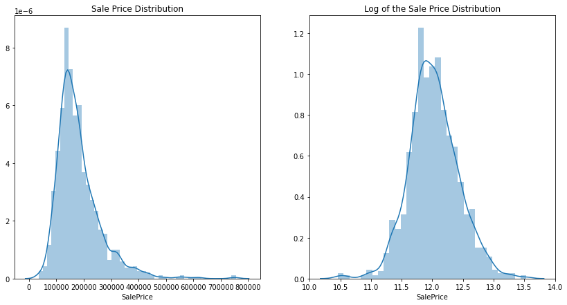

```python
fig = plt.figure(figsize=(14,7))
plt.subplot(1,2,1)
plt.title('Sale Price Distribution')
sns.distplot(train_vis['SalePrice'])
plt.subplot(1,2,2)
plt.title('Log of the Sale Price Distribution')
sns.distplot(np.log(train_vis['SalePrice']))
plt.show()
```

As said before, we can notice that the Sale Price distribution's deviates a bit from the Sale Price distribution. Taking the log gives us a curve that is much more similar to a normal distribution.

##### 1.1.2.b. Correlations between features

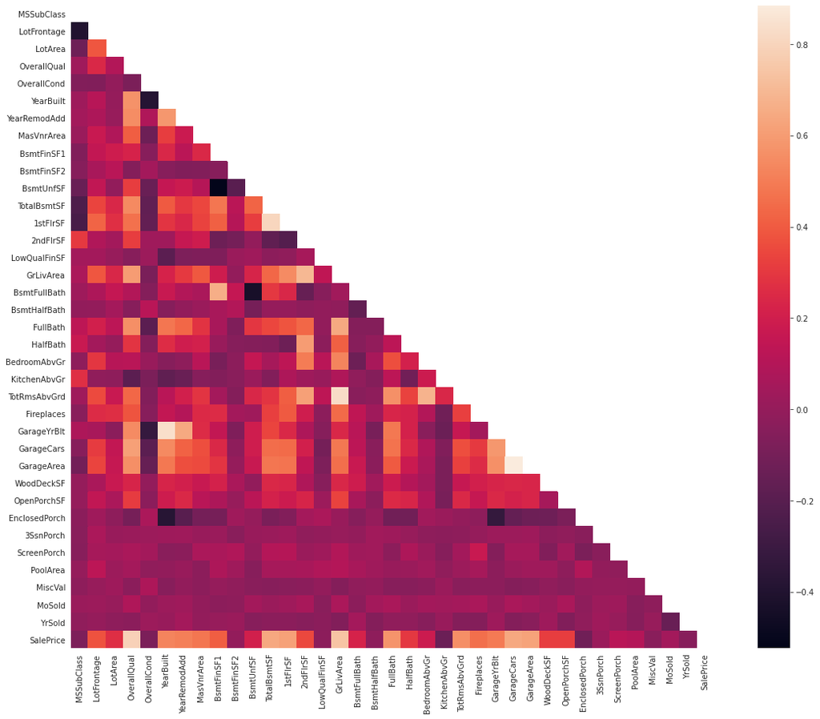

```python
fig = plt.figure(1, figsize=(20,15))
correlation_matrix = train_vis.corr()
mask = np.zeros_like(correlation_matrix)
mask[np.triu_indices_from(mask)] = True
with sns.axes_style("white"):
    ax = sns.heatmap(correlation_matrix, mask=mask, square=True)
```

##### 1.1.2.c. Sale Price correlation with other features

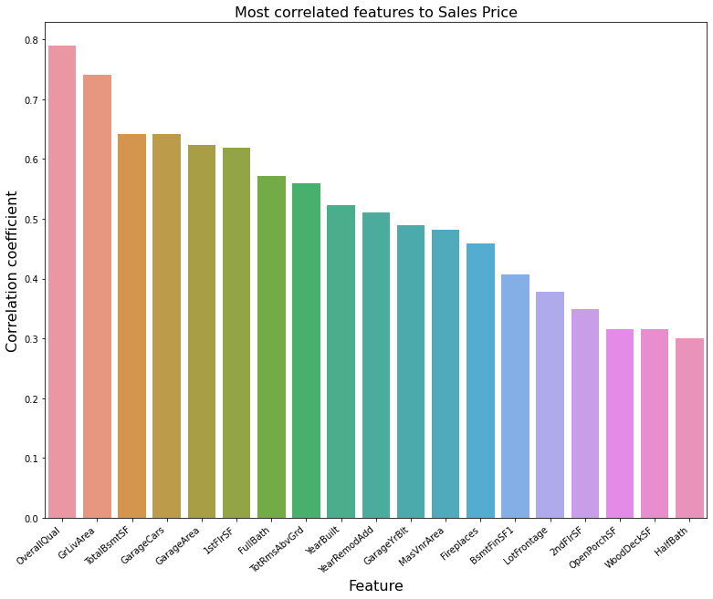

```python
corr_price = train_vis.corr(method="pearson").abs()

corr_price_hist = corr_price['SalePrice'].sort_values(ascending=False)[1:20]

fig, ax = plt.subplots(figsize=(13,10))
ax = sns.barplot(x=corr_price_hist.index, y=corr_price_hist.values)
ax.set_xticklabels(ax.get_xticklabels(), rotation=40, ha="right")

plt.xlabel('Feature', fontsize= 16)
plt.ylabel('Correlation coefficient', fontsize= 16)
plt.title('Most correlated features to Sales Price', fontsize=16)
plt.show()
```

```python
months = train_vis['MoSold'].unique()
years = train_vis['YrSold'].unique()
```

```python
train_vis['DateSold'] =  pd.to_datetime(train_vis.YrSold.astype(str) +'-' + train_vis.MoSold.astype(str))
```

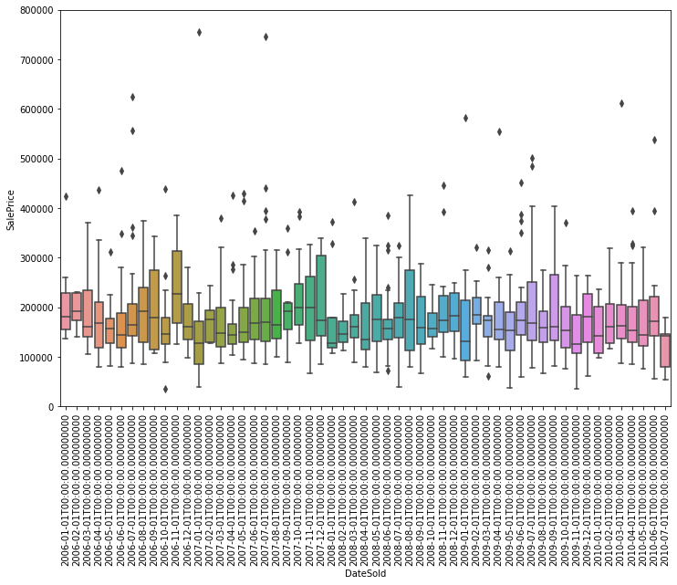

```python
var = 'DateSold'
data = pd.concat([train_vis['SalePrice'], train_vis[var]], axis=1)
f, ax = plt.subplots(figsize=(12, 8))
fig = sns.boxplot(x=var, y="SalePrice", data=data)
fig.axis(ymin=0, ymax=800000);
plt.xticks(rotation=90);
```

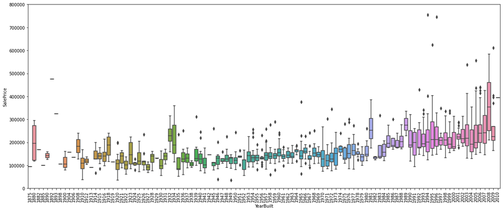

```python
var = 'YearBuilt'
data = pd.concat([train_vis['SalePrice'], train_vis[var]], axis=1)
f, ax = plt.subplots(figsize=(20, 8))
fig = sns.boxplot(x=var, y="SalePrice", data=data)
fig.axis(ymin=0, ymax=800000);
plt.xticks(rotation=90);
```

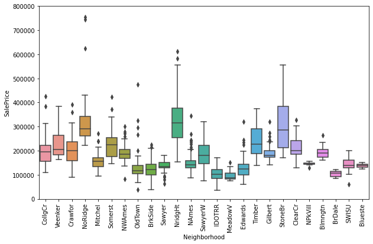

```python
var = 'Neighborhood'
data = pd.concat([train_vis['SalePrice'], train_vis[var]], axis=1)
f, ax = plt.subplots(figsize=(10, 6))
fig = sns.boxplot(x=var, y="SalePrice", data=data)
fig.axis(ymin=0, ymax=800000);
plt.xticks(rotation=90);
```

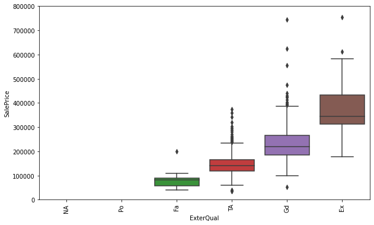

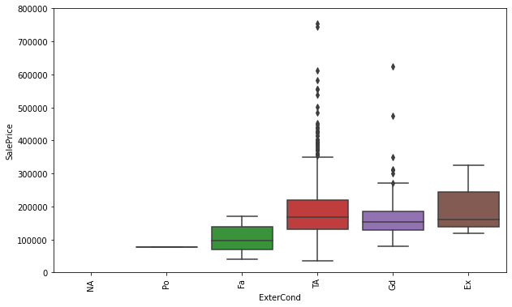

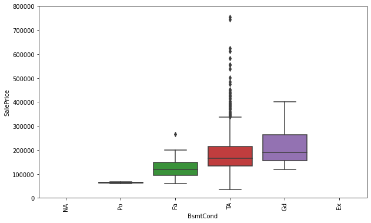

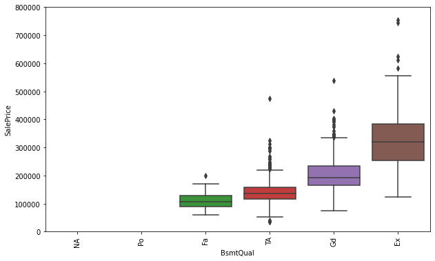

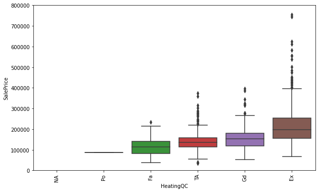

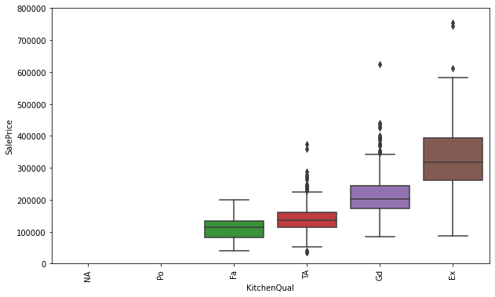

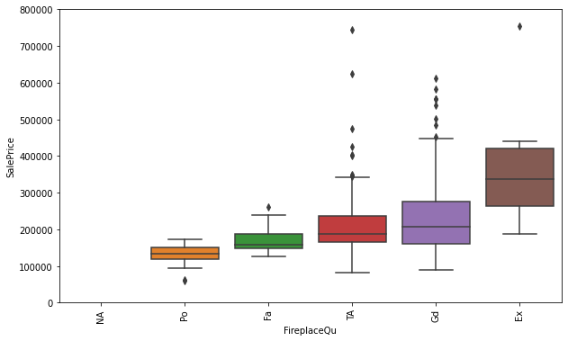

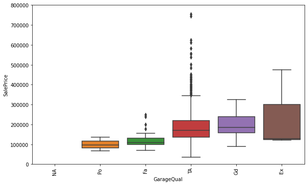

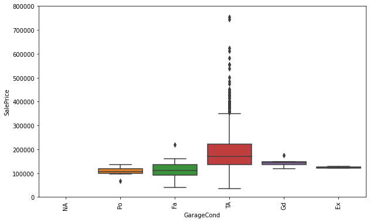

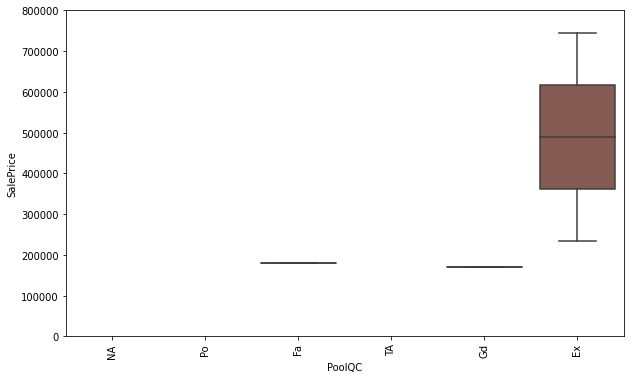

```python
categorical_features_scale1 = ['ExterQual', 'ExterCond',
                               'BsmtCond','BsmtQual',
                               'HeatingQC','KitchenQual','FireplaceQu',
                               'GarageQual','GarageCond','PoolQC']
categorical_features_scale2 = ['BsmtExposure']
categorical_features_scale3 = ['BsmtFinType1', 'BsmtFinType2']

for item in categorical_features_scale1:
  var = item
  data = pd.concat([train_vis['SalePrice'], train_vis[var]], axis=1)
  f, ax = plt.subplots(figsize=(10, 6))
  fig = sns.boxplot(x=var, y="SalePrice", data=data, order=['NA','Po','Fa','TA','Gd','Ex'])
  fig.axis(ymin=0, ymax=800000);
  plt.xticks(rotation=90);
```

These box plots show that choosing a numerical ordering for these features was not the dumbest thing to do.

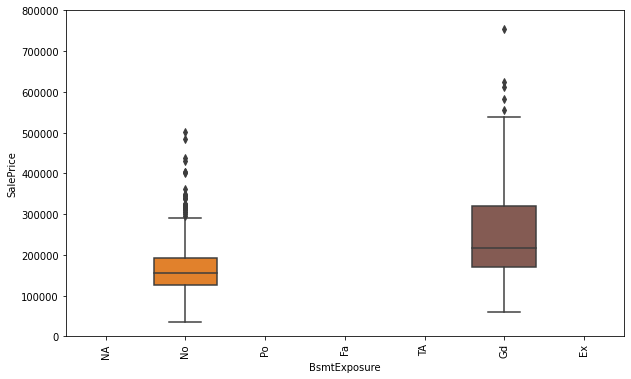

```python
  var = 'BsmtExposure'
  data = pd.concat([train_vis['SalePrice'], train_vis[var]], axis=1)
  f, ax = plt.subplots(figsize=(10, 6))
  fig = sns.boxplot(x=var, y="SalePrice", data=data, order=['NA','No','Po','Fa','TA','Gd','Ex'])
  fig.axis(ymin=0, ymax=800000);
  plt.xticks(rotation=90);
```

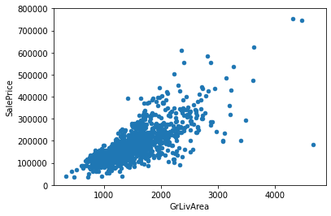

```python
var = 'GrLivArea'
data = pd.concat([train_vis['SalePrice'], train_vis[var]], axis=1)
data.plot.scatter(x=var, y='SalePrice', ylim=(0,800000));
```

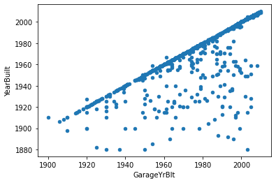

```python
var = 'GarageYrBlt'
data = pd.concat([train_vis['YearBuilt'], train_vis[var]], axis=1)
data.plot.scatter(x=var, y='YearBuilt');
```

##### 1.1.2.d. Detecting outliers manually

We'll try by looking at the features most correlated with Sale Price, detecting unregular houses.

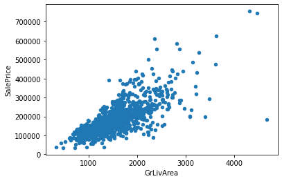

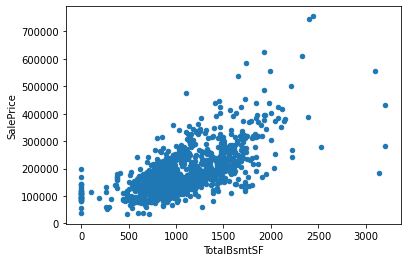

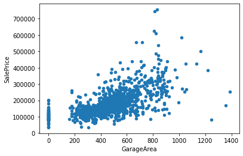

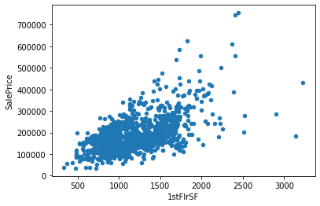

```python
outliers_features = ['GrLivArea','TotalBsmtSF','GarageArea','1stFlrSF']
for item in outliers_features:
  var = item
  data = pd.concat([train_vis['SalePrice'], train_vis[var]], axis=1)
  data.plot.scatter(x=var, y='SalePrice');
```

From the feature GrLivArea, we can notice that the biggest house of our dataset is very cheap and does not follow the trend. We can say the same of the two biggest houses in 1stFlrSF. We'll remove these outliers. The two houses are Id 523 and 496.

```python
train_vis.sort_values(by = 'GrLivArea', ascending = False)[:1]
```

|  | MSSubClass | MSZoning | LotFrontage | LotArea | Street | Alley | LotShape | LandContour | Utilities | LotConfig | LandSlope | Neighborhood | Condition1 | Condition2 | BldgType | HouseStyle | OverallQual | OverallCond | YearBuilt | YearRemodAdd | RoofStyle | RoofMatl | Exterior1st | Exterior2nd | MasVnrType | MasVnrArea | ExterQual | ExterCond | Foundation | … |
| --- | --- | --- | --- | --- | --- | --- | --- | --- | --- | --- | --- | --- | --- | --- | --- | --- | --- | --- | --- | --- | --- | --- | --- | --- | --- | --- | --- | --- | --- | --- |
| 523 | 60 | RL | 130.0 | 40094 | Pave | NaN | IR1 | Bnk | AllPub | Inside | Gtl | Edwards | PosN | PosN | 1Fam | 2Story | 10 | 5 | 2007 | 2008 | Hip | CompShg | CemntBd | CmentBd | Stone | 762.0 | Ex | TA | PConc | … |

1 rows × 81 columns

```python
train_vis.sort_values(by = '1stFlrSF', ascending = False)[:2]
```

|  | MSSubClass | MSZoning | LotFrontage | LotArea | Street | Alley | LotShape | LandContour | Utilities | LotConfig | LandSlope | Neighborhood | Condition1 | Condition2 | BldgType | HouseStyle | OverallQual | OverallCond | YearBuilt | YearRemodAdd | RoofStyle | RoofMatl | Exterior1st | Exterior2nd | MasVnrType | MasVnrArea | ExterQual | ExterCond | Foundation | … |
| --- | --- | --- | --- | --- | --- | --- | --- | --- | --- | --- | --- | --- | --- | --- | --- | --- | --- | --- | --- | --- | --- | --- | --- | --- | --- | --- | --- | --- | --- | --- |
| 496 | 20 | RL | NaN | 12692 | Pave | NaN | IR1 | Lvl | AllPub | Inside | Gtl | NoRidge | Norm | Norm | 1Fam | 1Story | 8 | 5 | 1992 | 1993 | Hip | CompShg | BrkFace | BrkFace | None | 0.0 | Gd | TA | PConc | … |
| 523 | 60 | RL | 130.0 | 40094 | Pave | NaN | IR1 | Bnk | AllPub | Inside | Gtl | Edwards | PosN | PosN | 1Fam | 2Story | 10 | 5 | 2007 | 2008 | Hip | CompShg | CemntBd | CmentBd | Stone | 762.0 | Ex | TA | PConc | … |

2 rows × 81 columns

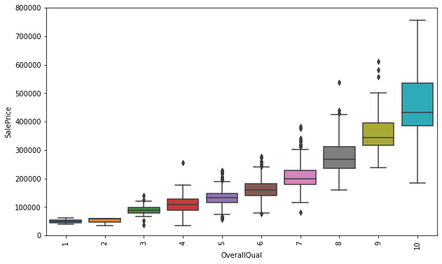

```python
var = 'OverallQual'
data = pd.concat([train_vis['SalePrice'], train_vis[var]], axis=1)
f, ax = plt.subplots(figsize=(10, 6))
fig = sns.boxplot(x=var, y="SalePrice", data=data)
fig.axis(ymin=0, ymax=800000);
plt.xticks(rotation=90);
```

```python
train_vis[train_vis['OverallQual'] == 4].sort_values(by='SalePrice', ascending=False).head()
```

|  | MSSubClass | MSZoning | LotFrontage | LotArea | Street | Alley | LotShape | LandContour | Utilities | LotConfig | LandSlope | Neighborhood | Condition1 | Condition2 | BldgType | HouseStyle | OverallQual | OverallCond | YearBuilt | YearRemodAdd | RoofStyle | RoofMatl | Exterior1st | Exterior2nd | MasVnrType | MasVnrArea | ExterQual | ExterCond | Foundation | … |
| --- | --- | --- | --- | --- | --- | --- | --- | --- | --- | --- | --- | --- | --- | --- | --- | --- | --- | --- | --- | --- | --- | --- | --- | --- | --- | --- | --- | --- | --- | --- |
| 457 | 20 | RL | NaN | 53227 | Pave | NaN | IR1 | Low | AllPub | CulDSac | Mod | ClearCr | Norm | Norm | 1Fam | 1Story | 4 | 6 | 1954 | 1994 | Flat | Tar&Grv | Plywood | Plywood | None | 0.0 | TA | TA | CBlock | … |
| 1020 | 20 | RL | 60.0 | 7024 | Pave | NaN | Reg | Lvl | AllPub | Inside | Gtl | Edwards | Norm | Norm | 1Fam | 1Story | 4 | 5 | 2005 | 2005 | Gable | CompShg | VinylSd | VinylSd | None | 0.0 | TA | TA | PConc | … |
| 1190 | 190 | RL | NaN | 32463 | Pave | NaN | Reg | Low | AllPub | Inside | Mod | Mitchel | Norm | Norm | 2fmCon | 1Story | 4 | 4 | 1961 | 1975 | Gable | CompShg | MetalSd | MetalSd | Stone | 149.0 | TA | Gd | CBlock | … |
| 405 | 20 | RL | NaN | 9991 | Pave | NaN | IR1 | Lvl | AllPub | Corner | Gtl | Sawyer | Feedr | Norm | 1Fam | 1Story | 4 | 4 | 1976 | 1993 | Gable | CompShg | Plywood | Plywood | None | 0.0 | TA | TA | CBlock | … |
| 942 | 90 | RL | 42.0 | 7711 | Pave | NaN | IR1 | Lvl | AllPub | Inside | Gtl | Edwards | Norm | Norm | Duplex | 1Story | 4 | 3 | 1977 | 1977 | Gable | CompShg | MetalSd | MetalSd | None | 0.0 | TA | TA | PConc | … |

5 rows × 81 columns

Also, the house number 457 has an OverallQual value of 4 (the most correlated feature to Sale Price) and seems to be a pretty decent outlier. We'll then remove it.

```python
rows_to_drop = [457,496,523]
```

At first, we decided to remove these outliers that we detected manually, but after reflection it seems that they can be unique houses, and we cannot check all the features individually to make sense of their prices, it is a bit arbitrary to remove them according to the distribution of one feature. We choose to keep them, and only use the sophisticated algorithm that can for itself check all the parameters before detecting an anomaly

### 1.2. Data pre-processing

#### 1.2.1. Converting the target values

As we described before, we convert the target prices into a logarithmic scale.

```python
y_train_log = np.log(y_train_clean)
y_test_log = np.log(y_test_clean)
```

#### 1.2.2. Removing the obvious outliers

```python
#X_train_clean = X_train_clean.drop(rows_to_drop,axis=0)
#y_train_log = y_train_log.drop(rows_to_drop,axis=0)
```

#### 1.2.3. Augmenting the dataset with external information / Combining existing features

Rich and Poor Neighboorhoods

#### 1.2.4. Feature scaling: Normalization and standardization

#### 1.2.5. Removing outliers

```python
y_train_log = y_train_log.reset_index().drop('index',axis=1)
X_train_clean = X_train_clean.reset_index().drop('index',axis=1)
```

```python
train_outliers = pd.concat([X_train_clean,y_train_log], axis = 1)
train_outliers
```

|  | MSSubClass | LotFrontage | LotArea | OverallQual | OverallCond | YearBuilt | YearRemodAdd | MasVnrArea | ExterQual | ExterCond | BsmtQual | BsmtCond | BsmtExposure | BsmtFinType1 | BsmtFinSF1 | BsmtFinType2 | BsmtFinSF2 | BsmtUnfSF | TotalBsmtSF | HeatingQC | CentralAir | 1stFlrSF | 2ndFlrSF | LowQualFinSF | GrLivArea | BsmtFullBath | BsmtHalfBath | FullBath | HalfBath | … |
| --- | --- | --- | --- | --- | --- | --- | --- | --- | --- | --- | --- | --- | --- | --- | --- | --- | --- | --- | --- | --- | --- | --- | --- | --- | --- | --- | --- | --- | --- | --- |
| 0 | 60.0 | 65.0 | 8450.0 | 7.0 | 5.0 | 2003.0 | 2003.0 | 196.0 | 5.0 | 4.0 | 5.0 | 4.0 | 2.0 | 7.0 | 706.0 | 2.0 | 0.0 | 150.0 | 856.0 | 6.0 | 1.0 | 856.0 | 854.0 | 0.0 | 1710.0 | 1.0 | 0.0 | 2.0 | 1.0 | … |
| 1 | 20.0 | 80.0 | 9600.0 | 6.0 | 8.0 | 1976.0 | 1976.0 | 0.0 | 4.0 | 4.0 | 5.0 | 4.0 | 5.0 | 6.0 | 978.0 | 2.0 | 0.0 | 284.0 | 1262.0 | 6.0 | 1.0 | 1262.0 | 0.0 | 0.0 | 1262.0 | 0.0 | 1.0 | 2.0 | 0.0 | … |
| 2 | 60.0 | 68.0 | 11250.0 | 7.0 | 5.0 | 2001.0 | 2002.0 | 162.0 | 5.0 | 4.0 | 5.0 | 4.0 | 3.0 | 7.0 | 486.0 | 2.0 | 0.0 | 434.0 | 920.0 | 6.0 | 1.0 | 920.0 | 866.0 | 0.0 | 1786.0 | 1.0 | 0.0 | 2.0 | 1.0 | … |
| 3 | 70.0 | 60.0 | 9550.0 | 7.0 | 5.0 | 1915.0 | 1970.0 | 0.0 | 4.0 | 4.0 | 4.0 | 5.0 | 2.0 | 6.0 | 216.0 | 2.0 | 0.0 | 540.0 | 756.0 | 5.0 | 1.0 | 961.0 | 756.0 | 0.0 | 1717.0 | 1.0 | 0.0 | 1.0 | 0.0 | … |
| 4 | 60.0 | 84.0 | 14260.0 | 8.0 | 5.0 | 2000.0 | 2000.0 | 350.0 | 5.0 | 4.0 | 5.0 | 4.0 | 4.0 | 7.0 | 655.0 | 2.0 | 0.0 | 490.0 | 1145.0 | 6.0 | 1.0 | 1145.0 | 1053.0 | 0.0 | 2198.0 | 1.0 | 0.0 | 2.0 | 1.0 | … |
| ... | ... | ... | ... | ... | ... | ... | ... | ... | ... | ... | ... | ... | ... | ... | ... | ... | ... | ... | ... | ... | ... | ... | ... | ... | ... | ... | ... | ... | ... | … |
| 1195 | 60.0 | 51.0 | 8029.0 | 6.0 | 5.0 | 2005.0 | 2005.0 | 0.0 | 4.0 | 4.0 | 5.0 | 4.0 | 2.0 | 2.0 | 0.0 | 2.0 | 0.0 | 728.0 | 728.0 | 6.0 | 1.0 | 728.0 | 728.0 | 0.0 | 1456.0 | 0.0 | 0.0 | 2.0 | 1.0 | … |
| 1196 | 60.0 | 58.0 | 14054.0 | 7.0 | 5.0 | 2006.0 | 2006.0 | 0.0 | 5.0 | 4.0 | 5.0 | 4.0 | 4.0 | 2.0 | 0.0 | 2.0 | 0.0 | 879.0 | 879.0 | 6.0 | 1.0 | 879.0 | 984.0 | 0.0 | 1863.0 | 0.0 | 0.0 | 2.0 | 1.0 | … |
| 1197 | 75.0 | 65.0 | 8850.0 | 7.0 | 6.0 | 1916.0 | 1950.0 | 0.0 | 4.0 | 4.0 | 4.0 | 4.0 | 2.0 | 2.0 | 0.0 | 2.0 | 0.0 | 815.0 | 815.0 | 6.0 | 1.0 | 815.0 | 875.0 | 0.0 | 1690.0 | 0.0 | 0.0 | 1.0 | 0.0 | … |
| 1198 | 20.0 | 70.0 | 9100.0 | 7.0 | 5.0 | 2001.0 | 2001.0 | 0.0 | 5.0 | 4.0 | 5.0 | 4.0 | 2.0 | 2.0 | 0.0 | 2.0 | 0.0 | 1212.0 | 1212.0 | 6.0 | 1.0 | 1212.0 | 0.0 | 0.0 | 1212.0 | 0.0 | 0.0 | 2.0 | 0.0 | … |
| 1199 | 20.0 | 75.0 | 11235.0 | 4.0 | 5.0 | 1963.0 | 1979.0 | 51.0 | 4.0 | 4.0 | 4.0 | 4.0 | 2.0 | 4.0 | 547.0 | 2.0 | 0.0 | 504.0 | 1051.0 | 5.0 | 1.0 | 1382.0 | 0.0 | 0.0 | 1382.0 | 0.0 | 0.0 | 1.0 | 1.0 | … |

1200 rows × 249 columns

```python
from sklearn.ensemble import IsolationForest


print('The shape of our train set before removing outliers is ' , train_outliers.shape)

isf = IsolationForest(max_samples = 100, random_state = 5)
isf.fit(train_outliers)

outliers = isf.predict(train_outliers)

#reorganising our dataframe
outliers = pd.DataFrame(outliers, columns = ['IsOutlier'])

#Removing the rows containing the outliers
train_outliers_removed = train_outliers.iloc[outliers[outliers['IsOutlier'] == 1].index.values]

print("Number of Outliers:", outliers[outliers['IsOutlier'] == -1].shape[0])
print("Number of rows without outliers:", train_outliers.shape[0])

print('The shape of our train set after removing outliers is ' , train_outliers_removed.shape)
```

[output not shown]

#### 1.2.6. Feature elimination / Feature reduction

```python
y_train = train_outliers['SalePrice']
X_train = train_outliers.drop('SalePrice', axis=1)
```

```python
X_test = X_test_clean
y_test = y_test_log
```

```python
X_train.head()
```

|  | MSSubClass | LotFrontage | LotArea | OverallQual | OverallCond | YearBuilt | YearRemodAdd | MasVnrArea | ExterQual | ExterCond | BsmtQual | BsmtCond | BsmtExposure | BsmtFinType1 | BsmtFinSF1 | BsmtFinType2 | BsmtFinSF2 | BsmtUnfSF | TotalBsmtSF | HeatingQC | CentralAir | 1stFlrSF | 2ndFlrSF | LowQualFinSF | GrLivArea | BsmtFullBath | BsmtHalfBath | FullBath | HalfBath | … |
| --- | --- | --- | --- | --- | --- | --- | --- | --- | --- | --- | --- | --- | --- | --- | --- | --- | --- | --- | --- | --- | --- | --- | --- | --- | --- | --- | --- | --- | --- | --- |
| 0 | 60.0 | 65.0 | 8450.0 | 7.0 | 5.0 | 2003.0 | 2003.0 | 196.0 | 5.0 | 4.0 | 5.0 | 4.0 | 2.0 | 7.0 | 706.0 | 2.0 | 0.0 | 150.0 | 856.0 | 6.0 | 1.0 | 856.0 | 854.0 | 0.0 | 1710.0 | 1.0 | 0.0 | 2.0 | 1.0 | … |
| 1 | 20.0 | 80.0 | 9600.0 | 6.0 | 8.0 | 1976.0 | 1976.0 | 0.0 | 4.0 | 4.0 | 5.0 | 4.0 | 5.0 | 6.0 | 978.0 | 2.0 | 0.0 | 284.0 | 1262.0 | 6.0 | 1.0 | 1262.0 | 0.0 | 0.0 | 1262.0 | 0.0 | 1.0 | 2.0 | 0.0 | … |
| 2 | 60.0 | 68.0 | 11250.0 | 7.0 | 5.0 | 2001.0 | 2002.0 | 162.0 | 5.0 | 4.0 | 5.0 | 4.0 | 3.0 | 7.0 | 486.0 | 2.0 | 0.0 | 434.0 | 920.0 | 6.0 | 1.0 | 920.0 | 866.0 | 0.0 | 1786.0 | 1.0 | 0.0 | 2.0 | 1.0 | … |
| 3 | 70.0 | 60.0 | 9550.0 | 7.0 | 5.0 | 1915.0 | 1970.0 | 0.0 | 4.0 | 4.0 | 4.0 | 5.0 | 2.0 | 6.0 | 216.0 | 2.0 | 0.0 | 540.0 | 756.0 | 5.0 | 1.0 | 961.0 | 756.0 | 0.0 | 1717.0 | 1.0 | 0.0 | 1.0 | 0.0 | … |
| 4 | 60.0 | 84.0 | 14260.0 | 8.0 | 5.0 | 2000.0 | 2000.0 | 350.0 | 5.0 | 4.0 | 5.0 | 4.0 | 4.0 | 7.0 | 655.0 | 2.0 | 0.0 | 490.0 | 1145.0 | 6.0 | 1.0 | 1145.0 | 1053.0 | 0.0 | 2198.0 | 1.0 | 0.0 | 2.0 | 1.0 | … |

5 rows × 248 columns

```python
X_train.to_csv('/content/drive/My Drive/AML/Chal1 - House/Data/X_train.csv', index=False)
X_test.to_csv('/content/drive/My Drive/AML/Chal1 - House/Data/X_test.csv', index=False)
y_train.to_csv('/content/drive/My Drive/AML/Chal1 - House/Data/y_train.csv', index= False)
y_test.to_csv('/content/drive/My Drive/AML/Chal1 - House/Data/y_test.csv', index=False)
```

#### 1.2.7 Other way of pre-processing (tried but not used)

```python
dataset_noskew = dataset.copy()
dataset_noskew

#log transform the target:
dataset_noskew["SalePrice"] = np.log1p(dataset_noskew["SalePrice"])

#log transform skewed numeric features:
numeric_feats = dataset_noskew.dtypes[dataset_noskew.dtypes != "object"].index

skewed_feats = dataset_noskew[numeric_feats].apply(lambda x: skew(x.dropna())) #compute skewness
skewed_feats = skewed_feats[skewed_feats > 0.75]
skewed_feats = skewed_feats.index

dataset_noskew[skewed_feats] = np.log1p(dataset_noskew[skewed_feats])

dataset_noskew = pd.get_dummies(dataset_noskew)
dataset_noskew = dataset_noskew.fillna(dataset_noskew.mean())
```

```python
train_clean_ns = (dataset_noskew[:test_index])
test_clean_ns = (dataset_noskew[test_index:])
```

## 2. Model Selection

```python
from sklearn.linear_model import LinearRegression
from sklearn.ensemble import RandomForestRegressor
import xgboost as xgb
from sklearn.linear_model import Ridge, Lasso, RidgeCV, LassoCV

from sklearn.model_selection import KFold, cross_val_score
from sklearn.model_selection import RandomizedSearchCV
from pprint import pprint
```

### 2.1. Models Testing

#### 2.1.1 A simple Linear regression

```python
start_linreg = time()
reg = LinearRegression().fit(X_train, y_train)
linreg_preds = reg.predict(X_train)
end_linreg = time()
time_linreg = end_linreg-start_linreg
```

```python
rmse_linreg = np.sqrt(mean_squared_error(linreg_preds, y_train))
```

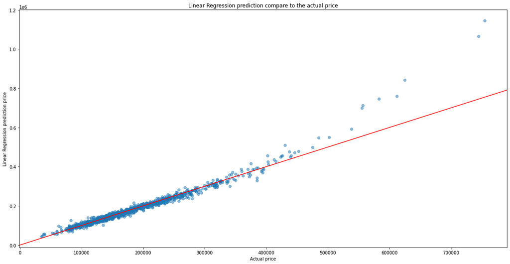

```python
fig, ax = plt.subplots(figsize=(20, 10))
xplot_linreg = np.exp(y_train.to_numpy())
yplot_linreg = np.exp(linreg_preds)

plt.xlabel('Actual price')
plt.ylabel('Linear Regression prediction price')
plt.title('Linear Regression prediction compare to the actual price')

ax.scatter(xplot_linreg, yplot_linreg, alpha=0.5)
line = mlines.Line2D(ax.get_xlim(), ax.get_xlim(), color='red')
ax.add_line(line)
```

#### 2.1.2. Defining a cross-validation strategy and testing it on various models

Here, we define a function using a cross-validation strategy, in order to validate more accurately our models. Using KFold and shuffling(cross-validation) and using cross_val_score with the right scoring.

```python
#Validation function
n_folds = 5

def rmse_cv(model, X, y):
    kf = KFold(n_folds, shuffle=True, random_state=42).get_n_splits(X)
    rmse = -cross_val_score(model, X, y, scoring="neg_root_mean_squared_error", cv = kf)
    return(rmse)
```

#### 2.1.3. Random Forest Regressor

```python
start_rfr = time()

rf = RandomForestRegressor(random_state = 42)
rf.fit(X_train,y_train)
rfr_preds = rf.predict(X_train)

end_rfr = time()
time_rfr = end_rfr-start_rfr

rmse_rfr = np.mean(rmse_cv(rf, X_train, y_train))
```

```python
# Look at parameters used by our current forest
print('Parameters currently in use:\n')
pprint(rf.get_params())
```

```
Parameters currently in use:

{'bootstrap': True,
 'ccp_alpha': 0.0,
 'criterion': 'mse',
 'max_depth': None,
 'max_features': 'auto',
 'max_leaf_nodes': None,
 'max_samples': None,
 'min_impurity_decrease': 0.0,
 'min_impurity_split': None,
 'min_samples_leaf': 1,
 'min_samples_split': 2,
 'min_weight_fraction_leaf': 0.0,
 'n_estimators': 100,
 'n_jobs': None,
 'oob_score': False,
 'random_state': 42,
 'verbose': 0,
 'warm_start': False}
```

This gives us all the parameters currently used in the random forest. There are a bit much and running a tuner on all these parameters would take a while. Reading the documentation of RandomForestRegressor, the most importants parameters seem to be:

- n_estimators: number of trees in the forest
- max_depth: The maximum depth of the tree
- min_samples_split: The minimum number of samples required to split an internal node
- min_samples_leaf: The minimum number of samples required to be at a leaf node

```python
n_estimators = [int(x) for x in np.linspace(start = 400, stop = 800, num = 5)]
max_depth = [int(x) for x in np.linspace(10, 40, num = 3)]
max_depth.append(None)
min_samples_split = [4, 5, 6]
min_samples_leaf = [1, 2, 4]

random_grid = {'n_estimators': n_estimators,
               'max_depth': max_depth,
               'min_samples_split': min_samples_split,
               'min_samples_leaf': min_samples_leaf}
pprint(random_grid)
```

```
{'max_depth': [10, 25, 40, None],
 'min_samples_leaf': [1, 2, 4],
 'min_samples_split': [4, 5, 6],
 'n_estimators': [400, 500, 600, 700, 800]}
```

We have a total of 4 *3* 3 * 5 = 180 combinations.

```python
rf = RandomForestRegressor()
rf_random = RandomizedSearchCV(estimator = rf, param_distributions = random_grid, n_iter = 10, cv = 3, verbose=2, random_state=42, n_jobs = -1, scoring='neg_root_mean_squared_error')
# Fit the random search model
rf_random.fit(X_train, y_train)
rf_random.best_params_
```

```
Fitting 3 folds for each of 10 candidates, totalling 30 fits
```

```
[Parallel(n_jobs=-1)]: Using backend LokyBackend with 2 concurrent workers.
[Parallel(n_jobs=-1)]: Done  30 out of  30 | elapsed:  3.2min finished
```

```
{'max_depth': None,
 'min_samples_leaf': 2,
 'min_samples_split': 4,
 'n_estimators': 700}
```

```python
base_model = RandomForestRegressor(n_estimators = 10, random_state = 42)
base_model.fit(X_train, y_train)
base_rmse = rmse_cv(base_model, X_train, y_train)

best_random = rf_random.best_estimator_
best_random.fit(X_train, y_train)
best_rmse = rmse_cv(best_random, X_train, y_train)

print('Base model RMSE: ')
print(base_rmse)
print('Best model RMSE: ')
print(best_rmse)
```

```
Base model RMSE:
[0.14999071 0.15681505 0.17156418 0.12353255 0.15121983]
Best model RMSE:
[0.13996634 0.14448853 0.17021084 0.11976099 0.13919228]
```

```python
best_random = rf_random.best_estimator_
best_random.fit(X_train, y_train)

rmse_rfr = np.mean(rmse_cv(best_random, X_train, y_train))
```

#### 2.1.4. XGBoost

```python
start_xgb = time()

xgb_model = xgb.XGBRegressor(objective="reg:squarederror", random_state=42)
xgb_model.fit(X_train, y_train)

xgb_preds = xgb_model.predict(X_train)

end_xgb = time()
time_xgb = end_xgb - start_xgb

rmse_xgb = np.mean(rmse_cv(xgb_model,X_train,y_train))
```

#### 2.1.5. Ridge

```python
[k*10**(-2) for k in range(25,27)]
```

```
[0.25, 0.26]
```

```
0.5
```

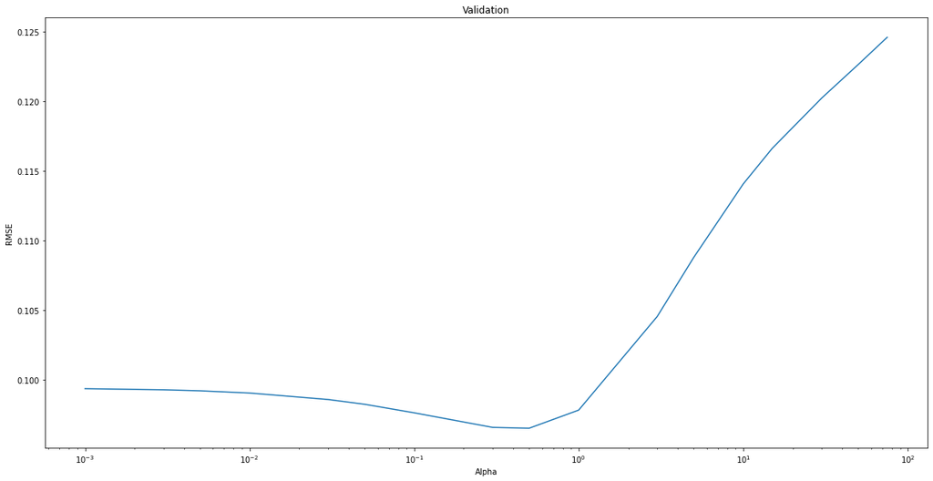

```python
alphas = [0.001, 0.003, 0.005, 0.01, 0.03, 0.05, 0.1, 0.3, 0.5, 1, 3, 5, 10, 15, 30, 50, 75]

cv_ridge = [rmse_cv(Ridge(alpha = alpha), X_train, y_train).mean() for alpha in alphas]
print(alphas[np.argmin(cv_ridge)])

cv_ridge = pd.Series(cv_ridge, index = alphas)
plt.figure(figsize=(20,10))
cv_ridge.plot(title = "Validation")
plt.xlabel("Alpha")
plt.ylabel("RMSE")
plt.xscale('log')
```

According to the plot above, alpha = 0.5 must be the best value for alpha in order to avoid both the overfitting and the underfitting.

```python
start_ridge = time()

best_model_ridge = Ridge(alpha=0.5)
best_model_ridge.fit(X_train, y_train)

ridge_preds = best_model_ridge.predict(X_train)

end_ridge = time()
time_ridge = end_ridge - start_ridge
```

```python
rmse_ridge = np.mean(rmse_cv(best_model_ridge, X_train, y_train))
```

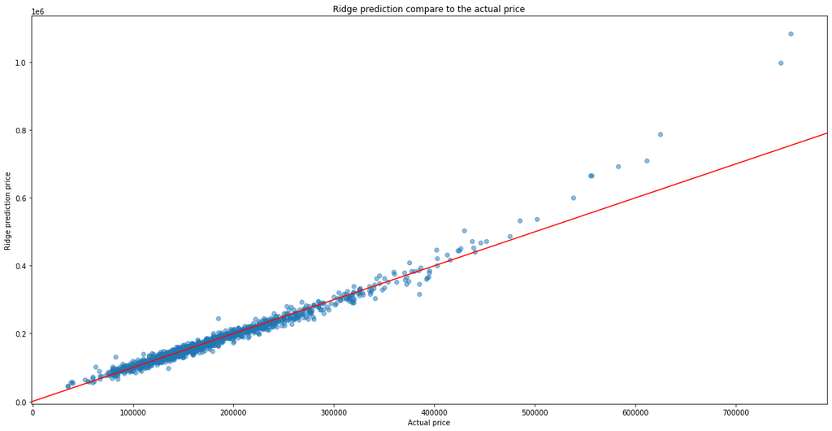

```python
fig, ax = plt.subplots(figsize=(20, 10))
xplot_ridge = np.exp(y_train.to_numpy())
yplot_ridge = np.exp(ridge_preds)

plt.xlabel('Actual price')
plt.ylabel('Ridge prediction price')
plt.title('Ridge prediction compare to the actual price')

ax.scatter(xplot_ridge, yplot_ridge, alpha=0.5)
line = mlines.Line2D(ax.get_xlim(), ax.get_xlim(), color='red')
ax.add_line(line)
```

#### 2.1.6. LASSO

[output not shown]

[output cut: 45 more lines]

[output not shown]

```
0.00037000000000000005
```

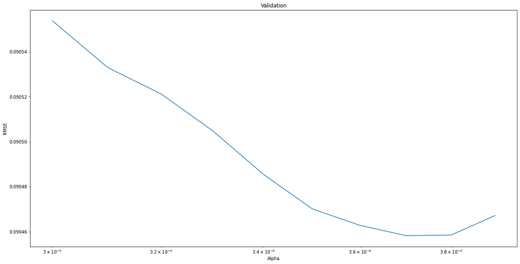

```python
alphas = [k*10**(-5) for k in range(30,40)]

cv_ridge = [rmse_cv(Lasso(alpha = alpha), X_train, y_train).mean() for alpha in alphas]
print(alphas[np.argmin(cv_ridge)])

cv_ridge = pd.Series(cv_ridge, index = alphas)
plt.figure(figsize=(20,10))
cv_ridge.plot(title = "Validation")
plt.xlabel("Alpha")
plt.ylabel("RMSE")
plt.xscale('log')
```

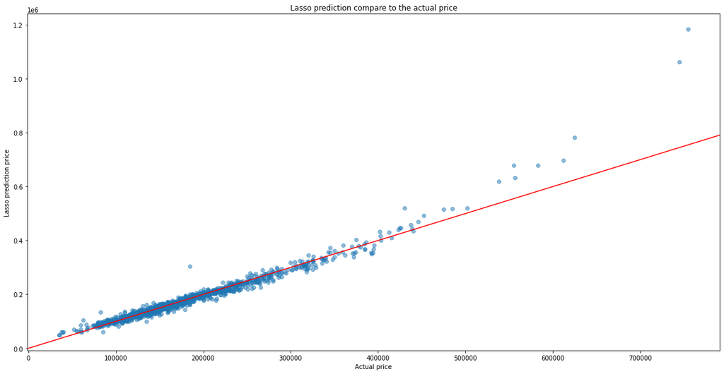

```python
start_lasso = time()

model_lasso = Lasso(alpha = 0.00038).fit(X_train, y_train)

lasso_preds = model_lasso.predict(X_train)

end_lasso = time()
time_lasso = end_lasso - start_lasso

rmse_lasso = np.mean(rmse_cv(model_lasso, X_train, y_train))

fig, ax = plt.subplots(figsize=(20, 10))
xplot_lasso = np.exp(y_train.to_numpy())
yplot_lasso = np.exp(lasso_preds)

plt.xlabel('Actual price')
plt.ylabel('Lasso prediction price')
plt.title('Lasso prediction compare to the actual price')

ax.scatter(xplot_lasso, yplot_lasso, alpha=0.5)
line = mlines.Line2D(ax.get_xlim(), ax.get_xlim(), color='red')
ax.add_line(line)
```

#### 2.1.7 Performance of our on training set

```python
r2_linreg = r2_score(np.exp(y_train), np.exp(linreg_preds))
r2_ridge = r2_score(np.exp(y_train), np.exp(ridge_preds))
r2_lasso = r2_score(np.exp(y_train), np.exp(lasso_preds))
r2_rfr = r2_score(np.exp(y_train), np.exp(rfr_preds))
r2_xgb = r2_score(np.exp(y_train), np.exp(xgb_preds))
```

```python
df_perf = pd.DataFrame(
    np.array([['Linear Regression', rmse_linreg, r2_linreg, time_linreg],
              ['Ridge', rmse_ridge, r2_ridge, time_ridge],
              ['Lasso', rmse_lasso, r2_lasso, time_lasso],
              ['Random Forest Regressor', rmse_rfr, r2_rfr, time_rfr],
              ['XGBoost', rmse_xgb, r2_xgb, time_xgb]]),
    columns=['Model', 'RMSE', 'R2', 'Running time (s)'])
```

```python
df_perf
```

|  | Model | RMSE | R2 | Running time (s) |
| --- | --- | --- | --- | --- |
| 0 | Linear Regression | 0.06779292744918337 | 0.9323776400088791 | 0.03951549530029297 |
| 1 | Ridge | 0.09651741682268829 | 0.9509151182859389 | 0.015266180038452148 |
| 2 | Lasso | 0.09045851444522116 | 0.9345991264803458 | 0.17964529991149902 |
| 3 | Random Forest Regressor | 0.1425908315651099 | 0.9804934663648475 | 2.7726879119873047 |
| 4 | XGBoost | 0.13537595860736823 | 0.9605645793925248 | 0.7817292213439941 |

```python
df_perf.to_csv('/content/drive/My Drive/AML/Chal1 - House/Data/perf_selection.csv')
```

We can notice that among all the model we tried that we have really good result from Linear Regression and it is not time consuming at all. While RandomForest Regressor and XGBoost are not really worth it here.

Then we will keep working and a linear model and will try to regularize it using Lasso, Ridge and Elastic and hypertune this models. We will then select the best model.

However we have to keep in mind that overfitting can occur so we need to be careful with our parameters.

### 2.2. Hypertuning LASSO / Ridge / ElasticNet

```python
from sklearn import linear_model
from sklearn.model_selection import GridSearchCV

start_hypertuning = time()

lasso_params = {'alpha':[0.0001, 0.00038, 0.001,0.01, 0.1, 1]}
ridge_params = {'alpha':[0.001,0.01, 0.1, 0.26, 1, 10, 100]}
elastic_parameters = {'alpha':[0.001,0.01, 0.1, 1, 10, 100],
                      'l1_ratio':[.1, .5, .7, .9, .95, .99, 1]}

models = {'Linear Regression': linear_model.LinearRegression(),
          'Lasso': GridSearchCV(linear_model.Lasso(max_iter=10000),scoring='neg_root_mean_squared_error',
                               param_grid=lasso_params).fit(X_train, y_train).best_estimator_,
          'Ridge': GridSearchCV(linear_model.Ridge(max_iter=10000),scoring='neg_root_mean_squared_error',
                               param_grid=ridge_params).fit(X_train, y_train).best_estimator_,
          'ElasticNet': GridSearchCV(linear_model.ElasticNet(max_iter=10000),scoring='neg_root_mean_squared_error',
                               param_grid=elastic_parameters).fit(X_train, y_train).best_estimator_,}

end_hypertuning = time()
time_hypertuning = end_hypertuning - start_hypertuning
```

[output not shown]

[output cut: 59 more lines]

[output not shown]

```python
def testing_models(models, X_train, y_train, X_test, y_test, iterations = 100):
    results = {}
    results['Metric'] = ['R2_train', 'R2_test', 'RMSE_train', 'RMSE_test', 'Running time (s)']
    for i in models:
        r2_train = []
        r2_test = []
        rmsecv_train = []
        rmsecv_test = []
        run_time = []

        for j in range(iterations):

            start_train = time()
            model_trained = models[i].fit(X_train, y_train)
            end_train = time()
            time_train = end_train - start_train
            run_time.append(time_train)

            r2_test.append(r2_score(y_test,model_trained.predict(X_test)))
            r2_train.append(r2_score(y_train, model_trained.predict(X_train)))

            rmsecv_test.append(np.sqrt(mean_squared_error(y_test, model_trained.predict(X_test))))
            rmsecv_train.append(np.mean(rmse_cv(model_trained, X_train, y_train)))

        results[i] = [np.mean(r2_train),
                      np.mean(r2_test),
                      np.mean(rmsecv_train),
                      np.mean(rmsecv_test),
                      np.mean(run_time)]
    return pd.DataFrame(results)
```

```python
model_tuned = testing_models(models, X_train, y_train, X_test, y_test, iterations = 1)
```

```python
model_tuned.to_csv('/content/drive/My Drive/AML/Chal1 - House/Data/model_tuned.csv')
```

```python
model_tuned
```

|  | Metric | Linear Regression | Lasso | Ridge | ElasticNet |
| --- | --- | --- | --- | --- | --- |
| 0 | R2_train | 0.971756 | 0.966089 | 0.971395 | 0.962270 |
| 1 | R2_test | 0.942664 | 0.946485 | 0.936464 | 0.927183 |
| 2 | RMSE_train | 0.099399 | 0.088286 | 0.096678 | 0.090956 |
| 3 | RMSE_test | 0.090973 | 0.087890 | 0.095766 | 0.102522 |
| 4 | Running time (s) | 0.033440 | 2.358953 | 0.009800 | 2.474352 |

## Model Performance

We will see how the hypertuned LASSO model perform on the testing set.

Here is the final model we will use:

*Lasso(alpha=0.00038, copy_X=True, fit_intercept=True, max_iter=10000, normalize=False, positive=False, precompute=False, random_state=None, selection='cyclic', tol=0.0001, warm_start=False)*

```python
models['Lasso']
```

```
Lasso(alpha=0.00038, copy_X=True, fit_intercept=True, max_iter=10000,
      normalize=False, positive=False, precompute=False, random_state=None,
      selection='cyclic', tol=0.0001, warm_start=False)
```

```python
best_lasso = models['Lasso'].fit(X_train, y_train)
```

```python
coef = pd.Series(best_lasso.coef_, index = X_train.columns)

print("Lasso picked " + str(sum(coef != 0)) + " variables and eliminated the other " +  str(sum(coef == 0)) + " variables")
```

```
Lasso picked 103 variables and eliminated the other 145 variables
```

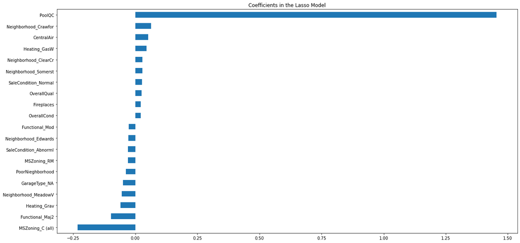

```python
imp_coef = pd.concat([coef.sort_values().head(10), coef.sort_values().tail(10)])

plt.figure(figsize=(20,10))
matplotlib.rcParams['figure.figsize'] = (8.0, 10.0)
imp_coef.plot(kind = "barh")
plt.title("Coefficients in the Lasso Model")
```

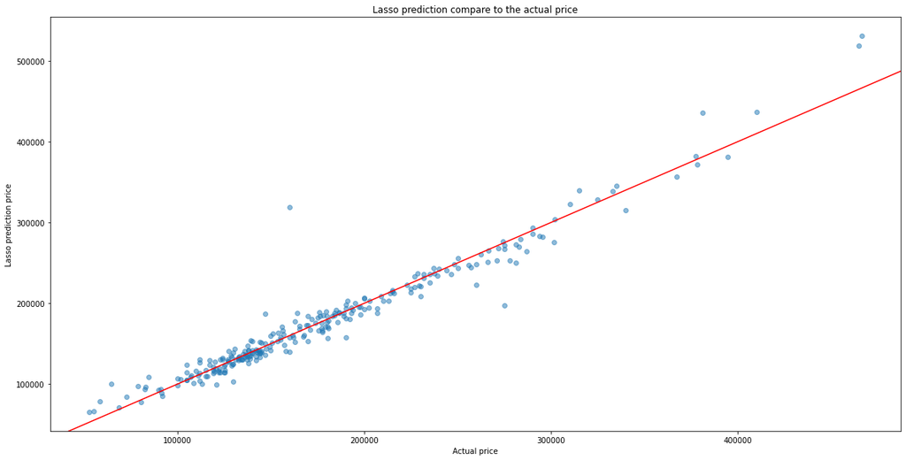

```python
rmse_lasso_best = np.sqrt(mean_squared_error(y_test, best_lasso.predict(X_test)))

lasso_preds_best = best_lasso.predict(X_test)

fig, ax = plt.subplots(figsize=(20, 10))
xplot_lasso_best = np.exp(y_test.to_numpy())
yplot_lasso_best = np.exp(lasso_preds_best)

plt.xlabel('Actual price')
plt.ylabel('Lasso prediction price')
plt.title('Lasso prediction compare to the actual price')

ax.scatter(xplot_lasso_best, yplot_lasso_best, alpha=0.5)
line = mlines.Line2D(ax.get_xlim(), ax.get_xlim(), color='red')
ax.add_line(line)
```

```python
avg_error = np.mean([abs((yplot_lasso_best[i]-xplot_lasso_best[i])/xplot_lasso_best[i])*100 for i in range(len(yplot_lasso_best))])
print('In average the predicted price is {}% wrong.'.format(avg_error))
```

```
In average the predicted price is 5.646837259094008% wrong.
```

Here we try to understance why there is is one skew predicted value on the upper left.

```python
index = np.argmax([abs(yplot_lasso_best[i]-xplot_lasso_best[i]) for i in range(len(yplot_lasso_best))])

#X_test.iloc[[index]]['PoolQC']
np.exp(y_test.iloc[index])
#X_test['LotArea'].mean()
```

```
159999.9999999999
```

[figure not shown]

```python
fig, ax = plt.subplots(figsize=(20, 10))
xplot_lasso_best_noskew = np.delete(xplot_lasso_best, index)
yplot_lasso_best_noskew = np.delete(yplot_lasso_best, index)

plt.xlabel('Actual price')
plt.ylabel('Lasso prediction price')
plt.title('Lasso prediction compare to the actual price')

ax.scatter(xplot_lasso_best_noskew, yplot_lasso_best_noskew, alpha=0.5)
line = mlines.Line2D(ax.get_xlim(), ax.get_xlim(), color='red')
ax.add_line(line)
```

```python
avg_error_noskew = np.mean([abs((yplot_lasso_best_noskew[i]-xplot_lasso_best_noskew[i])/xplot_lasso_best_noskew[i])*100 for i in range(len(yplot_lasso_best_noskew))])
print('In average the predicted price is {}% wrong.'.format(avg_error_noskew))
```

```
In average the predicted price is 5.286091964979209% wrong.
```